Dataset: Predict students' dropout and academic success

https://www.kaggle.com/datasets/thedevastator/higher-education-predictors-of-student-retention

Data explanantion https://www.mdpi.com/2306-5729/7/11/146

# Lab Assignment Five: Wide and Deep Network Architectures

Miller Boyd 47711811

## Introduction

In this lab, you will select a prediction task to perform on your dataset, evaluate two different deep learning architectures and tune hyper-parameters for each architecture. If any part of the assignment is not clear, ask the instructor to clarify.

This report is worth 10% of the final grade. Please upload a report (one per team) with all code used, visualizations, and text in a rendered Jupyter notebook. Any visualizations that cannot be embedded in the notebook, please provide screenshots of the output. The results should be reproducible using your report. Please carefully describe every assumption and every step in your report.

## Dataset Selection

Select a dataset similarly to lab one. That is, the dataset must be table data and must have categorical features. In terms of generalization performance, it is helpful to have a large dataset for building a wide and deep network. It is also helpful to have many different categorical features to create the embeddings and cross-product embeddings. It is fine to perform binary classification, multi-class classification, or regression. You are NOT allowed to use the census (i.e., Adult) dataset that was given as an example in class.

```python
import pandas as pd
import matplotlib.pyplot as plt

from sklearn.model_selection import train_test_split
from sklearn.preprocessing import MinMaxScaler, RobustScaler
import numpy as np
from sklearn.model_selection import RepeatedKFold
from sklearn.metrics import recall_score
import tensorflow as tf
from tensorflow.keras.models import Model
from tensorflow.keras.layers import Input, Dense, concatenate, Dropout

import warnings
warnings.filterwarnings('ignore', category=DeprecationWarning)
```

```python
# Data Loading

# Load the dataset into a pandas DataFrame
df = pd.read_csv('dataset.csv')

df.info()
df.describe()
```

```
<class 'pandas.core.frame.DataFrame'>
RangeIndex: 4424 entries, 0 to 4423
Data columns (total 35 columns):
 #   Column                                          Non-Null Count  Dtype
---  ------                                          --------------  -----
 0   Marital status                                  4424 non-null   int64
 1   Application mode                                4424 non-null   int64
 2   Application order                               4424 non-null   int64
 3   Course                                          4424 non-null   int64
 4   Daytime/evening attendance                      4424 non-null   int64
 5   Previous qualification                          4424 non-null   int64
 6   Nacionality                                     4424 non-null   int64
 7   Mother's qualification                          4424 non-null   int64
 8   Father's qualification                          4424 non-null   int64
 9   Mother's occupation                             4424 non-null   int64
```

[output cut: 27 more lines]

|  | Marital status | Application mode | Application order | Course | Daytime/evening attendance | Previous qualification | Nacionality | Mother's qualification | Father's qualification | Mother's occupation | ... | Curricular units 1st sem (without evaluations) | Curricular units 2nd sem (credited) | Curricular units 2nd sem (enrolled) | Curricular units 2nd sem (evaluations) | Curricular units 2nd sem (approved) | Curricular units 2nd sem (grade) | Curricular units 2nd sem (without evaluations) | Unemployment rate | Inflation rate | GDP |
| --- | --- | --- | --- | --- | --- | --- | --- | --- | --- | --- | --- | --- | --- | --- | --- | --- | --- | --- | --- | --- | --- |
| count | 4424.000000 | 4424.000000 | 4424.000000 | 4424.000000 | 4424.000000 | 4424.000000 | 4424.000000 | 4424.000000 | 4424.000000 | 4424.000000 | ... | 4424.000000 | 4424.000000 | 4424.000000 | 4424.000000 | 4424.000000 | 4424.000000 | 4424.000000 | 4424.000000 | 4424.000000 | 4424.000000 |
| mean | 1.178571 | 6.886980 | 1.727848 | 9.899186 | 0.890823 | 2.531420 | 1.254521 | 12.322107 | 16.455244 | 7.317812 | ... | 0.137658 | 0.541817 | 6.232143 | 8.063291 | 4.435805 | 10.230206 | 0.150316 | 11.566139 | 1.228029 | 0.001969 |
| std | 0.605747 | 5.298964 | 1.313793 | 4.331792 | 0.311897 | 3.963707 | 1.748447 | 9.026251 | 11.044800 | 3.997828 | ... | 0.690880 | 1.918546 | 2.195951 | 3.947951 | 3.014764 | 5.210808 | 0.753774 | 2.663850 | 1.382711 | 2.269935 |
| min | 1.000000 | 1.000000 | 0.000000 | 1.000000 | 0.000000 | 1.000000 | 1.000000 | 1.000000 | 1.000000 | 1.000000 | ... | 0.000000 | 0.000000 | 0.000000 | 0.000000 | 0.000000 | 0.000000 | 0.000000 | 7.600000 | -0.800000 | -4.060000 |
| 25% | 1.000000 | 1.000000 | 1.000000 | 6.000000 | 1.000000 | 1.000000 | 1.000000 | 2.000000 | 3.000000 | 5.000000 | ... | 0.000000 | 0.000000 | 5.000000 | 6.000000 | 2.000000 | 10.750000 | 0.000000 | 9.400000 | 0.300000 | -1.700000 |
| 50% | 1.000000 | 8.000000 | 1.000000 | 10.000000 | 1.000000 | 1.000000 | 1.000000 | 13.000000 | 14.000000 | 6.000000 | ... | 0.000000 | 0.000000 | 6.000000 | 8.000000 | 5.000000 | 12.200000 | 0.000000 | 11.100000 | 1.400000 | 0.320000 |
| 75% | 1.000000 | 12.000000 | 2.000000 | 13.000000 | 1.000000 | 1.000000 | 1.000000 | 22.000000 | 27.000000 | 10.000000 | ... | 0.000000 | 0.000000 | 7.000000 | 10.000000 | 6.000000 | 13.333333 | 0.000000 | 13.900000 | 2.600000 | 1.790000 |
| max | 6.000000 | 18.000000 | 9.000000 | 17.000000 | 1.000000 | 17.000000 | 21.000000 | 29.000000 | 34.000000 | 32.000000 | ... | 12.000000 | 19.000000 | 23.000000 | 33.000000 | 20.000000 | 18.571429 | 12.000000 | 16.200000 | 3.700000 | 3.510000 |

8 rows × 34 columns

### Preparation (4 points total)

#### Define and Prepare Your Class Variables (1 point)

- Describe your process for defining and preparing class variables, including the variable representations used (int, float, one-hot, etc.).
- Document any pre-processing methods for dimensionality reduction, scaling, etc.
- List and justify any variables that were removed.
- Provide a detailed description of the final dataset used for classification/regression, including any new variables you created.

```python
# snaitizing column names for ease of use

sanitized_names = {}
for col in df.columns:
    new_name = col.replace(" ", "_").replace("'", "").replace("-", "_")
    sanitized_names[col] = new_name

df = df.rename(columns=sanitized_names)
```

```python
# data sorting
# Columns that may contain outliers
robust_cols = ['Inflation_rate', 'GDP']
robust_scaler = RobustScaler()
df[robust_cols] = robust_scaler.fit_transform(df[robust_cols])

# Columns that are bound within a range
minmax_cols = ['Age_at_enrollment']
minmax_scaler = MinMaxScaler()
df[minmax_cols] = minmax_scaler.fit_transform(df[minmax_cols])

print(df.head())
```

```
   Marital_status  Application_mode  Application_order  Course  \
0               1                 8                  5       2
1               1                 6                  1      11
2               1                 1                  5       5
3               1                 8                  2      15
4               2                12                  1       3

   Daytime/evening_attendance  Previous_qualification  Nacionality  \
0                           1                       1            1
1                           1                       1            1
2                           1                       1            1
3                           1                       1            1
4                           0                       1            1

   Mothers_qualification  Fathers_qualification  Mothers_occupation  ...  \
```

[output cut: 42 more lines]

```python
# Define higher education as having any degree (assuming codes 2 to 34 represent degrees and advanced studies)
higher_education_codes = list(range(1, 6))  # Adjust this range based on the actual codes in your dataset

# Creating binary fields for mother's and father's education
df['Mother_Higher_Ed'] = df['Mothers_qualification'].apply(lambda x: 1 if x in higher_education_codes else 0)
df['Father_Higher_Ed'] = df['Fathers_qualification'].apply(lambda x: 1 if x in higher_education_codes else 0)
```

```python
from sklearn.preprocessing import LabelEncoder

# Instantiate the label encoder
label_encoder = LabelEncoder()

# Fit label encoder and return encoded labels for the training target variable
df['Target'] = label_encoder.fit_transform(df['Target'])

# To get the unique classes after encoding and their corresponding encoded values
unique_classes = label_encoder.classes_
unique_encoded = label_encoder.transform(unique_classes)

print("Unique classes:", unique_classes)
print("Encoded classes:", unique_encoded)
print("First few encoded values of y_train:", df['Target'].head())
```

```
Unique classes: ['Dropout' 'Enrolled' 'Graduate']
Encoded classes: [0 1 2]
First few encoded values of y_train: 0    0
1    2
2    0
3    2
4    2
Name: Target, dtype: int32
```

#### Identify Cross-product Features (1 point)

- Identify groups of features in your data that should be combined into cross-product features.
- Provide a justification for why these features should be crossed or not.

```python
import numpy as np

df['Scholarship_Debt_Cross'] = np.multiply(df['Scholarship_holder'], df['Debtor'])
df['Parent_Qual_Educ_Cross'] = np.multiply(df['Mother_Higher_Ed'], df['Father_Higher_Ed'])

print(df[['Parent_Qual_Educ_Cross', 'Scholarship_Debt_Cross']].head())
```

```
   Parent_Qual_Educ_Cross  Scholarship_Debt_Cross
0                       0                       0
1                       1                       0
2                       0                       0
3                       0                       0
4                       0                       0
```

1. Parental Education Levels (Mother and Father Higher Education)

Reasoning:

```
Enhanced Prediction: The combined educational level of both parents might provide a more comprehensive perspective on the home environment's intellectual and socioeconomic status, influencing student outcomes more than either parent's education alone.
Synergistic Effects: Two highly educated parents could create a nurturing environment that promotes the value of education, possibly leading to better academic results for their children.
```

2. Scholarship and Debt Status (Scholarship Holder and Debtor)

Reasoning:

```
Financial Context: This feature combination identifies students who benefit from financial aid yet also carry financial burdens. The interaction might affect their academic focus and stress levels, influencing performance.
Insightful Distinctions: Recognizing how scholarships and debts coexist can help tailor student support services more effectively, targeting specific needs based on their financial situations.
```

#### Evaluation Metrics (1 point)

- Choose and explain the metric(s) you will use to evaluate your algorithm’s performance.
- Provide a detailed argument for why the chosen metric(s) are appropriate for your data and the task at hand.

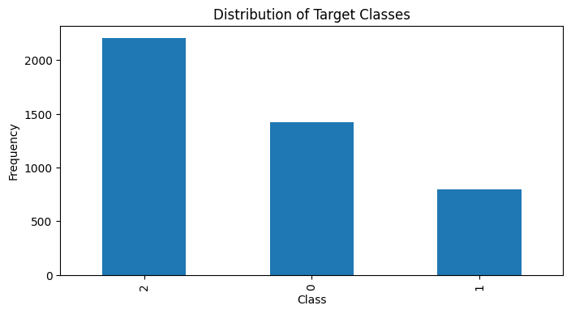

```python
# Plotting the distribution of the target variable
plt.figure(figsize=(8, 4))
df['Target'].value_counts().plot(kind='bar')
plt.title('Distribution of Target Classes')
plt.xlabel('Class')
plt.ylabel('Frequency')
plt.show()
```

#### Data Splitting Method (1 point)

- Choose and justify the method you will use for dividing your data into training and testing sets.
- Explain how this method is a realistic reflection of how an algorithm would be used in practice.

```python
from sklearn.model_selection import StratifiedShuffleSplit

# feature and target array setup
# X = np.array(df.drop('Target', axis=1))  # Features
# y = np.array(df['Target'])  # Target variable

X = df.drop('Target', axis=1) # Features
y = df['Target']  # Target variable


# Create the StratifiedShuffleSplit object
sss = StratifiedShuffleSplit(n_splits=1, test_size=0.2, random_state=42)

# Get indices for training and test sets
# Corrected code for splitting using indices from StratifiedShuffleSplit
for train_index, test_index in sss.split(X, y):
    X_train, X_test = X.iloc[train_index], X.iloc[test_index]
    y_train, y_test = y.iloc[train_index], y.iloc[test_index]
```

Stratified shuffle split is an ideal choice for datasets with imbalanced classes because it maintains the proportion of each class in both training and test sets, ensuring that the model learns to generalize across all classes. It also introduces randomness to reduce potential bias from the order in which data is presented, leading to a more robust evaluation of the model's performance on unseen data.

```python
X.describe()
#y.describe()
```

|  | Marital_status | Application_mode | Application_order | Course | Daytime/evening_attendance | Previous_qualification | Nacionality | Mothers_qualification | Fathers_qualification | Mothers_occupation | ... | Curricular_units_2nd_sem_(approved) | Curricular_units_2nd_sem_(grade) | Curricular_units_2nd_sem_(without_evaluations) | Unemployment_rate | Inflation_rate | GDP | Mother_Higher_Ed | Father_Higher_Ed | Scholarship_Debt_Cross | Parent_Qual_Educ_Cross |
| --- | --- | --- | --- | --- | --- | --- | --- | --- | --- | --- | --- | --- | --- | --- | --- | --- | --- | --- | --- | --- | --- |
| count | 4424.000000 | 4424.000000 | 4424.000000 | 4424.000000 | 4424.000000 | 4424.000000 | 4424.000000 | 4424.000000 | 4424.000000 | 4424.000000 | ... | 4424.000000 | 4424.000000 | 4424.000000 | 4424.000000 | 4424.000000 | 4424.000000 | 4424.000000 | 4424.000000 | 4424.000000 | 4424.000000 |
| mean | 1.178571 | 6.886980 | 1.727848 | 9.899186 | 0.890823 | 2.531420 | 1.254521 | 12.322107 | 16.455244 | 7.317812 | ... | 4.435805 | 10.230206 | 0.150316 | 11.566139 | -0.074770 | -0.091126 | 0.375226 | 0.296338 | 0.018987 | 0.214512 |
| std | 0.605747 | 5.298964 | 1.313793 | 4.331792 | 0.311897 | 3.963707 | 1.748447 | 9.026251 | 11.044800 | 3.997828 | ... | 3.014764 | 5.210808 | 0.753774 | 2.663850 | 0.601179 | 0.650411 | 0.484236 | 0.456694 | 0.136496 | 0.410530 |
| min | 1.000000 | 1.000000 | 0.000000 | 1.000000 | 0.000000 | 1.000000 | 1.000000 | 1.000000 | 1.000000 | 1.000000 | ... | 0.000000 | 0.000000 | 0.000000 | 7.600000 | -0.956522 | -1.255014 | 0.000000 | 0.000000 | 0.000000 | 0.000000 |
| 25% | 1.000000 | 1.000000 | 1.000000 | 6.000000 | 1.000000 | 1.000000 | 1.000000 | 2.000000 | 3.000000 | 5.000000 | ... | 2.000000 | 10.750000 | 0.000000 | 9.400000 | -0.478261 | -0.578797 | 0.000000 | 0.000000 | 0.000000 | 0.000000 |
| 50% | 1.000000 | 8.000000 | 1.000000 | 10.000000 | 1.000000 | 1.000000 | 1.000000 | 13.000000 | 14.000000 | 6.000000 | ... | 5.000000 | 12.200000 | 0.000000 | 11.100000 | 0.000000 | 0.000000 | 0.000000 | 0.000000 | 0.000000 | 0.000000 |
| 75% | 1.000000 | 12.000000 | 2.000000 | 13.000000 | 1.000000 | 1.000000 | 1.000000 | 22.000000 | 27.000000 | 10.000000 | ... | 6.000000 | 13.333333 | 0.000000 | 13.900000 | 0.521739 | 0.421203 | 1.000000 | 1.000000 | 0.000000 | 0.000000 |
| max | 6.000000 | 18.000000 | 9.000000 | 17.000000 | 1.000000 | 17.000000 | 21.000000 | 29.000000 | 34.000000 | 32.000000 | ... | 20.000000 | 18.571429 | 12.000000 | 16.200000 | 1.000000 | 0.914040 | 1.000000 | 1.000000 | 1.000000 | 1.000000 |

8 rows × 38 columns

### Modeling (5 points total)

#### Create Wide and Deep Networks (2 points)

- Create at least three combined wide and deep networks using Keras.
- Visualize the performance of each network on the training data and validation data in the same plot versus the training iterations.

```python
from tensorflow.keras.layers import Input, Dense, Embedding, Dropout, BatchNormalization, concatenate
from tensorflow.keras.models import Model

def create_wide_and_deep_model(num_features, num_deep_layers=3, deep_units=64):
    # Wide input part
    wide_input = Input(shape=(num_features,), name='wide_input')

    # Deep input part
    deep_input = Input(shape=(num_features,), name='deep_input')
    x = deep_input
    for i in range(num_deep_layers):
        x = Dense(deep_units, activation='relu', name=f'deep_layer_{i+1}')(x)
        # x = Dropout(0.5, name=f'dropout_{i+1}')(x)  # Adding dropout to prevent overfitting
        x = BatchNormalization(name=f'batch_norm_{i+1}')(x)  # Adding batch normalization to improve training stability

    # Combine wide and deep parts
    combined = concatenate([wide_input, x], name='concatenate_layer')
    outputs = Dense(1, activation='sigmoid', name='output_layer')(combined)  # Output layer

    # Create the model object
    model = Model(inputs=[wide_input, deep_input], outputs=outputs)

    # Compile the model
    model.compile(optimizer='adam',
                  loss='binary_crossentropy',
                  metrics=['Recall'])

    return model
```

```python
# Function to build, train, and evaluate the model
def build_model(X_train, X_test, y_train, y_test, num_deep_layers=3, deep_units=64):
    num_features = X.shape[1]
    model = create_wide_and_deep_model(num_features, num_deep_layers, deep_units)
    history = model.fit([X_train, X_train], y_train, validation_data=([X_test, X_test], y_test), epochs=10, batch_size=32, verbose=0)
    return model, history
```

```python
# Function to evaluate the model using Repeated K-Fold cross-validation
def evaluate_model(X, y, build_model_func):
    num_features = X.shape[1]
    recall_scores = []
    fold_number = 0

    # Create the StratifiedShuffleSplit object
    sss = StratifiedShuffleSplit(n_splits=4, test_size=0.4, random_state=42)

    # Get indices for training and test sets
    # splitting using indices from StratifiedShuffleSplit
    for train_index, test_index in sss.split(X, y):
        X_train, X_test = X.iloc[train_index], X.iloc[test_index]
        y_train, y_test = y.iloc[train_index], y.iloc[test_index]

        model, history = build_model_func(X_train, X_test, y_train, y_test)

        # Visualization for each fold
        plt.figure(figsize=(12, 6))
        plt.subplot(2, 2, 1)
        plt.plot(history.history['Recall'], label='Train Recall')
        plt.xlabel('Epoch')
        plt.ylabel('Recall')
        plt.title('Recall Over Epochs - Training')
        plt.legend()

        plt.subplot(2, 2, 2)
        plt.plot(history.history['val_Recall'], label='Validation Recall')
        plt.title('Recall Over Epochs - Validation')
        plt.xlabel('Epoch')
        plt.legend()

        plt.subplot(2, 2, 3)
        plt.plot(history.history['loss'], label='Training Loss')
        plt.ylabel('Loss')
        plt.xlabel('Epoch')
        plt.title('Loss Over Epochs - Training')
        plt.legend()

        plt.subplot(2, 2, 4)
        plt.plot(history.history['val_loss'], label='Validation Loss')
        plt.xlabel('Epoch')
        plt.title('Loss Over Epochs - Validation')
        plt.legend()

        plt.tight_layout()
        plt.show()

        # Compute recall at the end of the fold
        test_recall = recall_score(y_test, (model.predict([X_test, X_test]) > 0.5).astype(int), average='weighted')
        recall_scores.append(test_recall)
        print(f'Fold {fold_number} Test Recall: {test_recall:.3f}')
        fold_number += 1

    average_recall = np.mean(recall_scores)
    print(f"Average Recall across all folds: {average_recall:.3f}")
    return recall_scores
```

[output not shown]

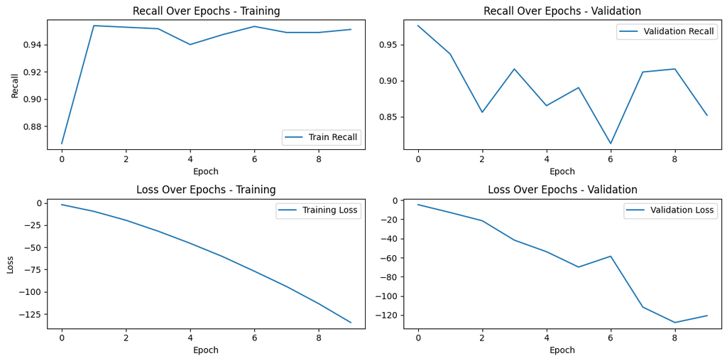

[output not shown]

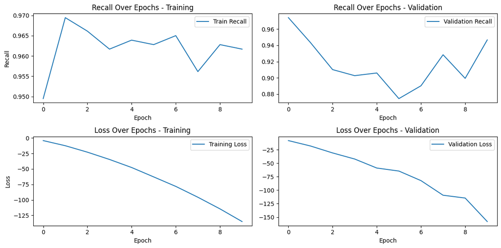

[output not shown]

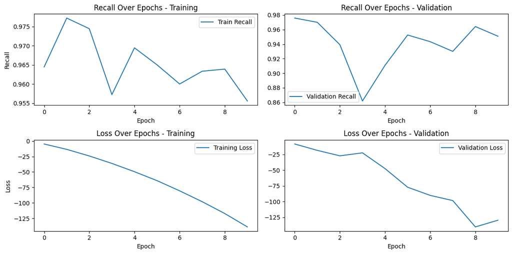

[output not shown]

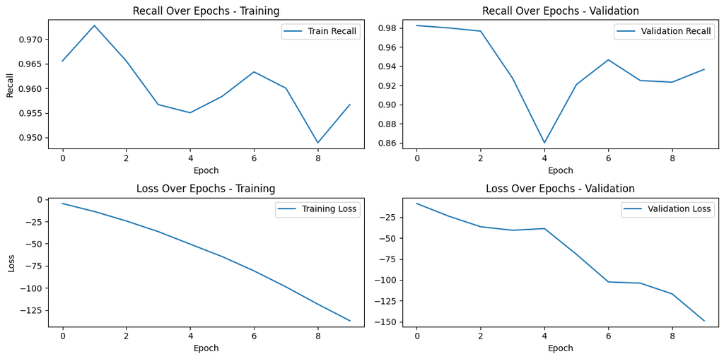

```
56/56 ━━━━━━━━━━━━━━━━━━━━ 0s 1ms/step
Fold 3 Test Recall: 0.364
Average Recall across all folds: 0.359
```

```python
m1_recall = evaluate_model(X, y, build_model)
```

Low Test Recall: The very low test recall underscores the model's poor generalization to new data.

Potential Improvements:

```
Crossing Columns: Adding wide network features like crossing columns could help the model learn feature interactions better.
L1/L2 Regularization: Implementing these in the deep layers might combat overfitting by penalizing complexity.
```

#### Investigate Generalization Performance (2 points)

- Alter the number of layers in the deep branch of the network and evaluate the performance.
- Compare the models using the chosen cross-validation method and evaluation metric to determine the superior model.
- Use proper statistical methods to compare different models’ performance.

```python
import numpy as np
from tensorflow.keras.layers import Input, Dense, Embedding, Dropout, BatchNormalization, concatenate, Lambda
from tensorflow.keras.models import Model
import tensorflow as tf

def create_wide_and_deep_model_2(cross_col_X_names, categorical_headers_ints, numeric_headers, X_train, X_test):
    # Crossed columns
    input_crossed = Input(shape=(X_train[cross_col_X_names].shape[1],), dtype='int64', name='crossed_input')
    crossed_outputs = []
    for idx, col in enumerate(cross_col_X_names):
        combined_series = pd.concat([X_train[col], X_test[col]])
        N = len(np.unique(combined_series))
        N_reduced = int(np.sqrt(N))
        x = Embedding(input_dim=N, output_dim=N_reduced, input_length=1, name=f'{col}_embed')(input_crossed[:, idx])
        crossed_outputs.append(x)
    wide_branch = concatenate(crossed_outputs, name='wide_concat')

    # Categorical columns
    input_cat = Input(shape=(X_train[categorical_headers_ints].shape[1],), dtype='int64', name='cat_input')
    cat_outputs = []
    for idx, col in enumerate(categorical_headers_ints):
        combined_series = pd.concat([X_train[col], X_test[col]])
        N = len(np.unique(combined_series))
        N_reduced = int(np.sqrt(N))
        x = Embedding(input_dim=N, output_dim=N_reduced, input_length=1, name=f'{col}_embed')(input_cat[:, idx])
        cat_outputs.append(x)
    cat_branch = concatenate(cat_outputs, name='cat_concat')

    # Numeric columns
    input_num = Input(shape=(X_train[numeric_headers].shape[1],), dtype='float32', name='num_input')
    num_branch = Dense(units=20, activation='relu', name='num_dense')(input_num)

    # Combine all deep branch outputs
    deep_branch = concatenate([cat_branch, num_branch], name='deep_concat')
    for i in range(5):
        deep_branch = Dense(units=64, activation='relu', name=f'deep_layer_{i+1}')(deep_branch)
        deep_branch = Dropout(0.5, name=f'dropout_{i+1}')(deep_branch)
        deep_branch = BatchNormalization(name=f'batch_norm_{i+1}')(deep_branch)

    # Merge the wide and deep branch
    final_branch = concatenate([wide_branch, deep_branch], name='final_concat')
    final_output = Dense(units=1, activation='sigmoid', name='final_output')(final_branch)

    # Create and compile the model
    model = Model(inputs=[input_crossed, input_cat, input_num], outputs=final_output)
    model.compile(optimizer='adam', loss='binary_crossentropy', metrics=['Recall'])

    return model
```

```python
import numpy as np
import pandas as pd
from sklearn.model_selection import train_test_split

def build_model_2(cross_col_X_names, categorical_headers_ints, numeric_headers, X_train, X_test, y_train, y_test, X_train_crossed, X_train_cat, X_train_num, X_test_crossed, X_test_cat, X_test_num):

    # Build the model
    model = create_wide_and_deep_model_2(cross_col_X_names, categorical_headers_ints, numeric_headers, X_train, X_test)

    # Train the model
    history = model.fit([X_train_crossed, X_train_cat, X_train_num], y_train,
                        validation_data=([X_test_crossed, X_test_cat, X_test_num], y_test),
                        epochs=10, batch_size=32, verbose=0)

    return model, history
```

```python
# Function to evaluate the model using Repeated K-Fold cross-validation
def evaluate_model_2(X, y):
    num_features = X.shape[1]
    recall_scores = []
    fold_number = 0

    # Correct the column names and setup based on actual dataframe usage
    categorical_headers_ints = [
        'Marital_status', 'Nacionality', 'Application_mode', 'Course',
        'Previous_qualification', "Mothers_qualification", "Fathers_qualification",
        "Mothers_occupation", "Fathers_occupation"
    ]

    # Only numeric columns that are not binary, crossed, or categorical
    numeric_headers = [
        col for col in X.columns
        if X[col].dtype in ['int64', 'float64']
        and col not in (categorical_headers_ints + ['Scholarship_holder', 'Debtor', 'Mother_Higher_Ed', 'Father_Higher_Ed', 'Scholarship_Debt_Cross', 'Parent_Qual_Educ_Cross'])
    ]

    cross_col_X_names = ['Scholarship_Debt_Cross', 'Parent_Qual_Educ_Cross']

    # Create the StratifiedShuffleSplit object
    sss = StratifiedShuffleSplit(n_splits=4, test_size=0.2, random_state=42)

    # Get indices for training and test sets
    # splitting using indices from StratifiedShuffleSplit
    for train_index, test_index in sss.split(X, y):
        X_train, X_test = X.iloc[train_index], X.iloc[test_index]
        y_train, y_test = y.iloc[train_index], y.iloc[test_index]

        # Prepare the data
        X_train_crossed = X_train[cross_col_X_names].to_numpy()
        X_test_crossed = X_test[cross_col_X_names].to_numpy()

        X_train_cat = X_train[categorical_headers_ints].to_numpy()
        X_test_cat = X_test[categorical_headers_ints].to_numpy()

        X_train_num = X_train[numeric_headers].to_numpy()
        X_test_num = X_test[numeric_headers].to_numpy()

        model, history = build_model_2(cross_col_X_names, categorical_headers_ints, numeric_headers, X_train, X_test, y_train, y_test, X_train_crossed, X_train_cat, X_train_num, X_test_crossed, X_test_cat, X_test_num,)

        # Visualization for each fold
        plt.figure(figsize=(12, 6))
        plt.subplot(2, 2, 1)
        plt.plot(history.history['Recall'], label='Train Recall')
        plt.xlabel('Epoch')
        plt.ylabel('Recall')
        plt.title('Recall Over Epochs - Training')
        plt.legend()

        plt.subplot(2, 2, 2)
        plt.plot(history.history['val_Recall'], label='Validation Recall')
        plt.title('Recall Over Epochs - Validation')
        plt.xlabel('Epoch')
        plt.legend()

        plt.subplot(2, 2, 3)
        plt.plot(history.history['loss'], label='Training Loss')
        plt.ylabel('Loss')
        plt.xlabel('Epoch')
        plt.title('Loss Over Epochs - Training')
        plt.legend()

        plt.subplot(2, 2, 4)
        plt.plot(history.history['val_loss'], label='Validation Loss')
        plt.xlabel('Epoch')
        plt.title('Loss Over Epochs - Validation')
        plt.legend()

        plt.tight_layout()
        plt.show()

        # Compute recall at the end of the fold
        test_predictions = model.predict([X_test_crossed, X_test_cat, X_test_num])
        test_recall = recall_score(y_test, (test_predictions > 0.5).astype(int), average='weighted')
        recall_scores.append(test_recall)

        print(f'Fold {fold_number} Test Recall: {test_recall:.3f}')
        fold_number += 1

    average_recall = np.mean(recall_scores)
    print(f"Average Recall across all folds: {average_recall:.3f}")
    return recall_scores
```

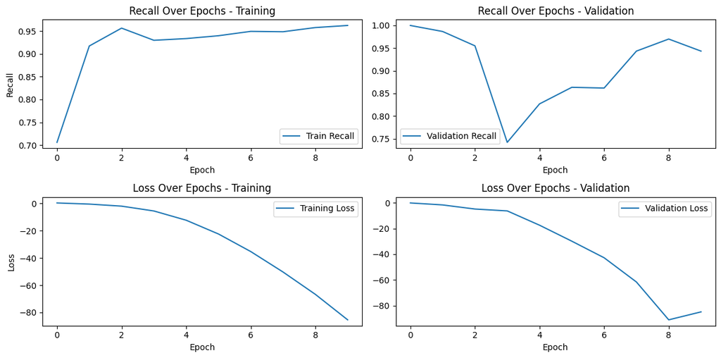

```
28/28 ━━━━━━━━━━━━━━━━━━━━ 0s 5ms/step
Fold 0 Test Recall: 0.365
```

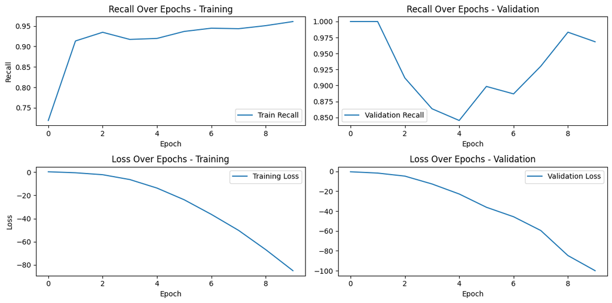

```
28/28 ━━━━━━━━━━━━━━━━━━━━ 0s 5ms/step
Fold 1 Test Recall: 0.346
```

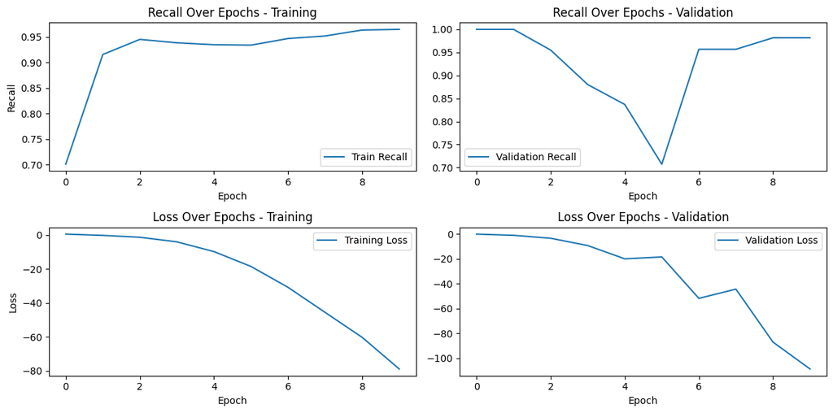

```
28/28 ━━━━━━━━━━━━━━━━━━━━ 0s 5ms/step
Fold 2 Test Recall: 0.341
```

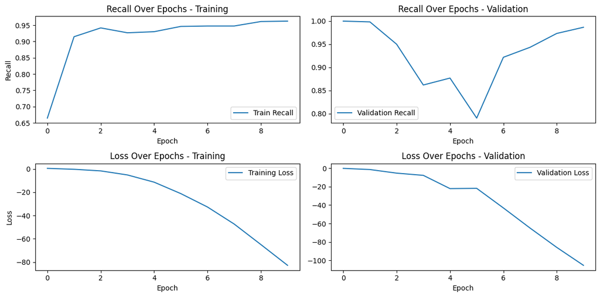

```
28/28 ━━━━━━━━━━━━━━━━━━━━ 0s 5ms/step
Fold 3 Test Recall: 0.321
Average Recall across all folds: 0.343
```

```python
m2_recall = evaluate_model_2(X, y)
```

- Compare your best wide and deep network to a standard MLP or a deep-only network.
- Use the appropriate statistical methods and visualizations to compare performance for classification or regression tasks.

### Exceptional Work (1 point total)

#### Additional Analyses for 5000 Level Students

- Provide additional analyses as you see fit for the dataset and the task.

#### Embedding Analysis for 7000 Level Students (Required)

- Capture and analyze the embedding weights from the deep network.
- If necessary, perform dimensionality reduction on these weights.
- Visualize and explain any clusters or patterns observed in the data.